# Project 1 : National Footprint Accounts 2018

**Meenakshi Nerolu** $\hspace{18cm}$ **October 20, 2019**

# 1. Introduction

> National Footprint and Biocapacity Accounts (NFAs) provide the core data required for all Ecological Footprint analysis worldwide. Every year, Global Footprint Network produces a new edition of its National Footprint Accounts, which calculate Ecological Footprint and biocapacity. The calculations in the National Footprint and Biocapacity Accounts are based on United Nations or UN affiliated data sets. Global Footprint Network is able to provide time series of both Ecological Footprint and biocapacity. The Ecological Footprint uses yields of primary products (from cropland, forest, grazing land and fisheries) to calculate the area necessary to support a given activity.

### Data Description

Data Source: https://www.kaggle.com/footprintnetwork/national-footprint-accounts-2018

> This data set shows results for 196 countries for data years 1961 through 2014, the most recent year with complete data. For each country and year, Ecological Footprint of Consumption, also just called Ecological Footprint, and Biocapacity as well as Ecological Footprint of Production and trade in both total global hectares and global hectares per capita are reported.

> The columns "crop_land" through "carbon" are the number of global hectares of this landtype either required to support consumption/production (Ecological Footprint of Consumption, Production), or that are supported by biological productivity (Biocapacity). The "total" column is the sum of these values.

> The goal of this is to produce accounts of how much area is required to provide the ecological services consumed by humanity ("Ecological Footprint"), and how much biologically productive area exists to provide these ecological services ("biocapacity") in each year. With both values in hand, we can assess the overall sustainability of countries around the world and better understand the collective need for humanity to reduce its impact on nature.

This dataset contains following 15 variables:

- **Country**
  - Country Name.
- **ISO alpha-3 code**
- **UN_region**
  - Region of the country.
- **UN_subregion**
  - Subregion of the country.
- **Year**
  - Year in which values are calculated.
- **Record**
  - Description of reported global hectares.
- **Crop_land**
  - Global hectares of crop land (used for crops & crop-derived products) available or demanded. Biocapacity = Footprint of  
    production because all biocapacity is used for production.
- **Grazing_land**
  - Global hectares of grazing land (used for meat, dairy, leather, etc.) available or demanded. Includes global hectares used for grazing, but not crop land used to produce feed for animals.
- **Forest_land**
  - Global hectares of forest land available (for sequestration and timber, pulp, or timber products) or demanded (for  
    timber, pulp, or timber products).
- **Fishing_ground**
  - Global hectares of marine and inland fishing grounds (used for fish & fish products) available or demanded.
- **Built_up_land**
  - Global hectares of built-up land (land cover of human infrastructure) available or demanded. Not traded. Biocapacity equals Footprint of Production because 100% of biocapacity covered counts as that demanded by infrastructure coverage.
- **Carbon**
  - Global hectares of world-average forest required to sequester carbon emissions.
- **Total**
  - The sum of all land types for this country, year, and record.
- **Percapita GDP (2010 USD)**
  - Per capita GDP in constant 2010 USD.
- **Population**
  - Population rounded to thousands.

# 2. Data Preparation with Numpy and Pandas

## Numpy

**NumPy** is the fundamental package for scientific computing with Python. NumPy can also be used as an efficient multi-dimensional container of generic data. Arbitrary data-types can be defined. This allows NumPy to seamlessly and speedily integrate with a wide variety of databases.

## Pandas

**Pandas** is an open source library providing high-performance, easy-to-use data structures and data analysis tools for the Python programming language. It is written for the Python programming language for data manipulation and analysis. In particular, it offers data structures and operations for manipulating numerical tables and time series.

#### To use Numpy and Pandas, we first need to import the numpy & pandas packages:

```python
import numpy as np
import pandas as pd
```

### Reading csv file :

```python
#data frame from csv file
NFA2018 = pd.read_csv("NFA_2018.csv")
```

### Dimension of the dataframe :

```python
np.shape(NFA2018)
```

```
(87020, 15)
```

```python
NFA2018.shape
```

```
(87020, 15)
```

This Dataset may contain some missing information. Hence I am dropping the rows where at least one element is missing. The following python code perfoms this operation.

```python
# Making new data frame with dropped NA values
NFA2018_new=NFA2018.dropna()
# dimension of the new dataframe
NFA2018_new.shape
```

```
(54330, 15)
```

```python
# comparing sizes of data frames
print("Old data frame length:", len(NFA2018), "\nNew data frame length:",
       len(NFA2018_new))
```

```
Old data frame length: 87020
New data frame length: 54330
```

```python
# First 3 rows in the dataframe
NFA2018_new.head(3)
```

|  | country | ISO alpha_3 | UN_region | UN_subregion | year | record | crop_land | grazing_land | forest_land | fishing_ground | built_up_land | carbon | total | Percapita_GDP | population |
| --- | --- | --- | --- | --- | --- | --- | --- | --- | --- | --- | --- | --- | --- | --- | --- |
| 0 | Armenia | ARM | Asia | Western Asia | 1992 | BiocapPerCap | 0.161129 | 0.135023 | 0.083836 | 0.013718 | 0.033669 | 0.000000 | 4.273741e-01 | 949.033 | 3449000 |
| 1 | Armenia | ARM | Asia | Western Asia | 1992 | BiocapTotGHA | 555812.972600 | 465763.337400 | 289190.662300 | 47320.224590 | 116139.598200 | 0.000000 | 1.474227e+06 | 949.033 | 3449000 |
| 2 | Armenia | ARM | Asia | Western Asia | 1992 | EFConsPerCap | 0.390923 | 0.189137 | 0.000001 | 0.004138 | 0.033669 | 1.112225 | 1.730092e+00 | 949.033 | 3449000 |

# 3. EDA principles and the Matplotlib packages to visualize the data

> In statistics, **Exploratory Data Analysis (EDA)** is an approach to analyzing data sets to summarize their main characteristics, often with visual methods. For reading data and performing EDA operations, we’ll primarily use the numpy and pandas Python packages, which offer simple API’s that allow us to plug our data sources and perform our desired operation. For the output, we’ll be using the Seaborn package which is a Python-based data visualization library built on Matplotlib. It provides a high-level interface for drawing attractive and informative statistical graphics. Data visualization is an important part of analysis since it allows even non-programmers to be able to decipher trends and patterns.

Exploratory Data Analysis is useful in:

- Understanding the underlying data at a deeper level.
- Bringing important aspects of the data into focus which are not easy to find using summary statistics like mean, mode,  
  median, correlation, covariance, variance, standard deviation and other statistical measures.
- Identifying important features in the dataset.
- Finding the relationship between variables.
- Identifying erroneous and outliers in the dataset.
- Performing a hypothesis test on the dataset.

```python
# Load the package matploatlib
import matplotlib.pyplot as plt
import seaborn as sns
```

# 4. histogram, barplot, boxplot, or scatterplot

## Basic Exploratory Data Analysis Techniques in Python

### *Scatterplot* :

Scatter plot is used to display two correlated variables on $x$ and $y$ axis considering $x$ as independent and $y$ as dependent variable. Scatterplot will help us in identifying how $x$ and $y$ are changing together.

```python
is_2011 =  NFA2018_new['year'] == 2011
NFA2018_scatter = NFA2018_new[is_2011]
NFA2018_scatter.shape
```

```
(1310, 15)
```

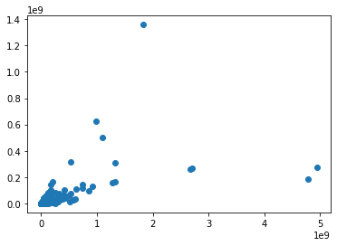

```python
plt.scatter(NFA2018_scatter.total, NFA2018_scatter.forest_land)
```

### Labeling axes

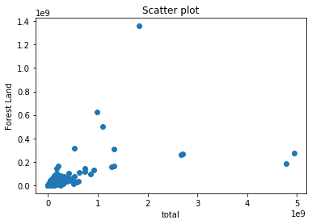

```python
plt.scatter(NFA2018_scatter.total, NFA2018_scatter.forest_land)
#Title
plt.title('Scatter plot')
#Labeling x axis
plt.xlabel('total')
# Labeling y axis
plt.ylabel('Forest Land')
```

### *Histogram* :

Histogram generally used to plot a single column value which creates equal sized bins on $x$ axis. $y$ axis shows the total count of the values falling inside a bin range. The height of the bin shows that how many values are falling in a particular bin. We can manually set the size of the bins. Lets have a look at the histogram of $x$ and $y$ data for all the NFA datasets.

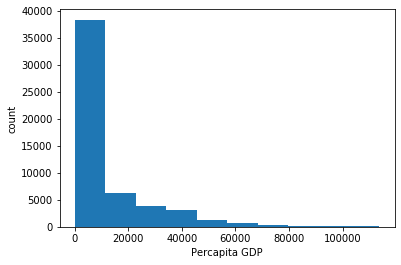

```python
plt.hist(NFA2018_new.Percapita_GDP)
plt.xlabel('Percapita GDP')
plt.ylabel('count')
```

# 5. Nonparametric inference of the Median for a quantitative variable - Bootstrapping

## Bootstrapping

> Bootstrapping is any test or metric that relies on random sampling with replacement. Bootstrapping allows assigning measures of accuracy to sample estimates. This technique allows estimation of the sampling distribution of almost any statistic using random sampling methods.
- The basic idea of bootstrapping is:
  - simulate data from one or more plausible ‘models’,
  - apply the same procedure to the simulated data sets as was applied to the original data, and
  - then analyse the results.
- Bootstrap is used to find :
  - standard errors for estimators;
  - confidence intervals for unknown parameters; or
  - p-values for test statistics under a null hypothesis.

```python
NFA2018_new.describe()
```

|  | year | crop_land | grazing_land | forest_land | fishing_ground | built_up_land | carbon | total | Percapita_GDP | population |
| --- | --- | --- | --- | --- | --- | --- | --- | --- | --- | --- |
| count | 54330.000000 | 5.433000e+04 | 5.433000e+04 | 5.433000e+04 | 5.433000e+04 | 5.433000e+04 | 5.433000e+04 | 5.433000e+04 | 54330.000000 | 5.433000e+04 |
| mean | 1991.150745 | 7.744275e+06 | 3.204618e+06 | 8.116228e+06 | 2.042132e+06 | 7.931547e+05 | 1.474430e+07 | 3.664470e+07 | 11043.275472 | 4.356898e+07 |
| std | 15.168254 | 3.733184e+07 | 1.487819e+07 | 5.548825e+07 | 9.433126e+06 | 6.137841e+06 | 1.103329e+08 | 1.853537e+08 | 16428.456071 | 1.434889e+08 |
| min | 1961.000000 | 0.000000e+00 | 0.000000e+00 | 0.000000e+00 | 0.000000e+00 | 0.000000e+00 | 0.000000e+00 | 1.515768e-03 | 115.794000 | 1.130000e+05 |
| 25% | 1979.000000 | 3.151253e-01 | 8.072040e-02 | 1.799788e-01 | 3.551980e-02 | 0.000000e+00 | 2.438768e-02 | 1.373126e+00 | 776.843000 | 3.570000e+06 |
| 50% | 1993.000000 | 3.446406e+00 | 2.989496e+00 | 4.193340e+00 | 4.184065e+00 | 3.412537e-02 | 1.475490e+00 | 3.681368e+03 | 2970.040000 | 9.087000e+06 |
| 75% | 2004.000000 | 2.297903e+06 | 7.008065e+05 | 1.742550e+06 | 3.260079e+05 | 6.285169e+04 | 1.193828e+06 | 1.174223e+07 | 15786.300000 | 2.810600e+07 |
| max | 2014.000000 | 8.148728e+08 | 2.022626e+08 | 1.495331e+09 | 1.731391e+08 | 1.715442e+08 | 3.688446e+09 | 5.212416e+09 | 113682.000000 | 1.400602e+09 |

Pandas **describe()** is used to view some basic statistical details like percentile, mean, std etc. of a data frame or a series of numeric values.

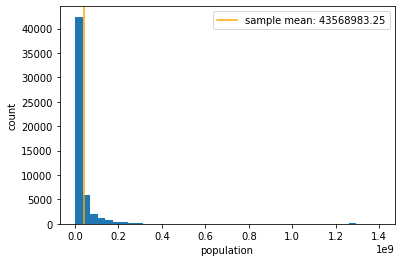

```python
x = NFA2018_new['population'].values
x_mean = np.mean(x)
plt.hist(x, bins=40)
plt.axvline(x_mean, color='orange', label='sample mean: %.2f' % x_mean)
plt.xlabel('population')
plt.ylabel('count')
plt.legend(loc=1)
plt.show()
```

```python
def bootstrap_means(x, n_bootstrap_samples, seed=None):

    rng = np.random.RandomState(seed)
    sample_means = np.zeros(shape=n_bootstrap_samples)

    for i in range(n_bootstrap_samples):
        boot_sample = rng.choice(x, size=x.shape[0], replace=True)
        # replicate is a general term for a statistic computed
        # from a bootstrap sample
        bootstrap_replicate = np.mean(boot_sample)
        sample_means[i] = bootstrap_replicate
    return sample_means
```

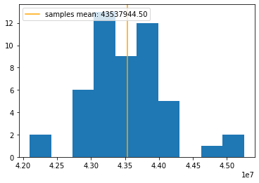

```python
boot_50 = bootstrap_means(x, n_bootstrap_samples=50, seed=123)

boot_mean = np.mean(boot_50)
plt.hist(boot_50, bins=10)
plt.axvline(boot_mean, color='orange', label='samples mean: %.2f' % boot_mean)
plt.legend(loc=2)
plt.show()
```

```python
means_boot_samples = []
for i in range(1000):
                boot_sample = np.random.choice(NFA2018_new.population, 100)
                means_boot_samples.append(boot_sample.mean())

np.mean(means_boot_samples)
```

```
43360175.17
```

```python
np.median(means_boot_samples)
```

```
41847400.0
```

```python
np.std(means_boot_samples)
```

```
14415480.564169727
```

```python
conf_int = np.percentile(means_boot_samples, [2.5, 97.5]) # The middle 95% interval
conf_int
```

```
array([20745575.  , 74865829.25])
```

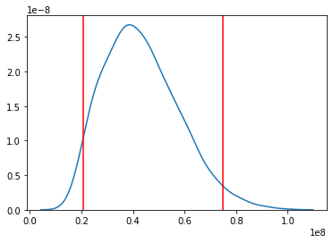

```python
sns.kdeplot(means_boot_samples)
for endpoint in conf_int:
    plt.axvline(endpoint, color='red')
```